# Lesson 2 - Data Visualization Complementary Views

## Instructions

1. Create different complementary views of data by applying multiple chart types and aesthetics.
2. Project multiple dimensions using conditioning or faceting (e.g., small multiples) on both categorical and numeric variables.

### Conclusions

For this Casino Head Count data set, I wanted to identify the **most busy periods** and **most popular games** in the casino's operation. As an indicator, I used the average hourly head count and tables occupied.

I thought about using 'small multiples' but could not figure out what kind of data could be put into them. Moreover, with the data which is all about time and counts, I can't think of 'multiple chart types' that can be used.

1. Months 3, 5, 6, 7 seem to be most busy on average, with Months 4 and 8 being the least busy on average. See this section.
2. Weekly averages provide a more granular view than monthly average breakdowns. See this section.
3. Fridays, Saturdays and Sundays are the most busy days. See this section.
4. As for the peak hours of day, there are two busy periods - from 14:00 to 17:00 and from 20:00 to 02:00. See this section.
5. The three most popular games throughout the year are CR, S6 and TP. See these plots.

```python
# Load necessary libraries
import pandas as pd
import numpy as np
import matplotlib.pyplot as plt
%matplotlib inline
```

```python
# Location of dataset
url = 'https://library.startlearninglabs.uw.edu/DATASCI410/Datasets/JitteredHeadCount.csv'
filename = 'JitteredHeadCount.csv'
```

### Load the dataset

```python
# Load data
def load_data(a_url, path):
    """Load data from a url or local path."""
    print("Loading the data set from a local file if it exists...")
    try:
        data_set = pd.read_csv(path)
        print("Data set loaded from a local file.")
    except FileNotFoundError:
        print("File not found, loading from Internet...")
        data_set = pd.read_csv(a_url)
        print("Data set loaded from the Internet.")

    return data_set

headcount_df = load_data(url, filename)
```

```
Loading the data set from a local file if it exists...
Data set loaded from a local file.
```

### Examine the data frames and summary statistics

```python
# Look at the summary statistics for this data set
headcount_df.describe()
```

|  | Hour | TablesOcc | TablesOpen | TablesClosed | HeadCount | DayOfWeek | DayNumber |
| --- | --- | --- | --- | --- | --- | --- | --- |
| count | 175677.000000 | 175677.000000 | 175677.000000 | 175677.000000 | 175677.000000 | 175677.000000 | 175677.000000 |
| mean | 11.504431 | 2.074591 | 2.555804 | 1.853430 | 7.390228 | 3.992953 | 183.434303 |
| std | 6.922330 | 3.307518 | 3.673229 | 2.993767 | 12.458613 | 1.997989 | 105.702167 |
| min | 0.000000 | 0.000000 | 0.000000 | 0.000000 | 0.000000 | 1.000000 | 1.000000 |
| 25% | 6.000000 | 0.000000 | 1.000000 | 0.000000 | 0.000000 | 2.000000 | 92.000000 |
| 50% | 12.000000 | 1.000000 | 1.000000 | 1.000000 | 3.000000 | 4.000000 | 183.000000 |
| 75% | 18.000000 | 2.000000 | 3.000000 | 3.000000 | 8.000000 | 6.000000 | 275.000000 |
| max | 23.000000 | 24.000000 | 24.000000 | 23.000000 | 109.000000 | 7.000000 | 366.000000 |

```python
# Look at the first and last few lines of the dataframe
headcount_df.head()
```

|  | GameCode | DateFormat | Hour | TablesOcc | TablesOpen | TablesClosed | HeadCount | DayOfWeek | DayNumber |
| --- | --- | --- | --- | --- | --- | --- | --- | --- | --- |
| 0 | BA | 9/16/2011 | 6 | 0 | 0 | 1 | 0 | 6 | 47 |
| 1 | BA | 9/16/2011 | 7 | 0 | 0 | 1 | 0 | 6 | 47 |
| 2 | BA | 9/16/2011 | 8 | 0 | 0 | 1 | 0 | 6 | 47 |
| 3 | BA | 9/16/2011 | 9 | 0 | 0 | 1 | 0 | 6 | 47 |
| 4 | BA | 9/16/2011 | 10 | 0 | 1 | 0 | 0 | 6 | 47 |

```python
headcount_df.tail()
```

|  | GameCode | DateFormat | Hour | TablesOcc | TablesOpen | TablesClosed | HeadCount | DayOfWeek | DayNumber |
| --- | --- | --- | --- | --- | --- | --- | --- | --- | --- |
| 175672 | WR | 10/31/2011 | 19 | 0 | 0 | 1 | 0 | 2 | 92 |
| 175673 | WR | 10/31/2011 | 20 | 1 | 1 | 0 | 1 | 2 | 92 |
| 175674 | WR | 10/31/2011 | 21 | 0 | 1 | 0 | 0 | 2 | 92 |
| 175675 | WR | 10/31/2011 | 22 | 1 | 1 | 0 | 1 | 2 | 92 |
| 175676 | WR | 10/31/2011 | 23 | 0 | 1 | 0 | 0 | 2 | 92 |

```python
# Number of rows and columns; dtypes and number of unique values in attributes
def dtypes_unique(df):
    """Return a df of dtypes and numbers of unique values in the df for pretty printing."""
    dtypes_unique_vals = pd.DataFrame({'dtypes': df.dtypes})
    unique_vals = []
    for var in df.columns:
        unique_vals.append(len(df.loc[:, var].unique()))
    # Add the number of unique values to this dataframe
    dtypes_unique_vals['unique_vals'] = unique_vals

    return dtypes_unique_vals

print(headcount_df.shape)
print(dtypes_unique(headcount_df))
```

```
(175677, 9)
              dtypes  unique_vals
GameCode      object           22
DateFormat    object          366
Hour           int64           24
TablesOcc      int64           25
TablesOpen     int64           25
TablesClosed   int64           24
HeadCount      int64          110
DayOfWeek      int64            7
DayNumber      int64          366
```

### Add timestamp index to the dataset

```python
# Combine DateFormat and Hour into one TimeStamp attribute and make it the index for the dataframe
headcount_df['TimeStamp'] = pd.to_datetime(headcount_df.DateFormat) + headcount_df.Hour.astype('timedelta64[h]')
headcount_df.set_index('TimeStamp', inplace = True)
```

```python
# Look at a particular date and hour by using the newly created index
headcount_df['2011-9-21 01:00:00']
```

| TimeStamp | GameCode | DateFormat | Hour | TablesOcc | TablesOpen | TablesClosed | HeadCount | DayOfWeek | DayNumber |
| --- | --- | --- | --- | --- | --- | --- | --- | --- | --- |
| 2011-09-21 01:00:00 | BA | 9/21/2011 | 1 | 0 | 0 | 1 | 0 | 4 | 52 |
| 2011-09-21 01:00:00 | C4 | 9/21/2011 | 1 | 1 | 1 | 0 | 5 | 4 | 52 |
| 2011-09-21 01:00:00 | CR | 9/21/2011 | 1 | 3 | 4 | 2 | 8 | 4 | 52 |
| 2011-09-21 01:00:00 | DH | 9/21/2011 | 1 | 2 | 3 | 2 | 3 | 4 | 52 |
| 2011-09-21 01:00:00 | FP | 9/21/2011 | 1 | 3 | 3 | 2 | 7 | 4 | 52 |
| 2011-09-21 01:00:00 | LI | 9/21/2011 | 1 | 2 | 4 | 0 | 7 | 4 | 52 |
| 2011-09-21 01:00:00 | MI | 9/21/2011 | 1 | 1 | 1 | 0 | 1 | 4 | 52 |
| 2011-09-21 01:00:00 | MQ | 9/21/2011 | 1 | 0 | 0 | 1 | 0 | 4 | 52 |
| 2011-09-21 01:00:00 | MR | 9/21/2011 | 1 | 0 | 1 | 2 | 0 | 4 | 52 |
| 2011-09-21 01:00:00 | ND | 9/21/2011 | 1 | 0 | 0 | 2 | 0 | 4 | 52 |
| 2011-09-21 01:00:00 | PA | 9/21/2011 | 1 | 0 | 0 | 1 | 0 | 4 | 52 |
| 2011-09-21 01:00:00 | PG | 9/21/2011 | 1 | 0 | 1 | 0 | 0 | 4 | 52 |
| 2011-09-21 01:00:00 | RO | 9/21/2011 | 1 | 2 | 3 | 3 | 5 | 4 | 52 |
| 2011-09-21 01:00:00 | RR | 9/21/2011 | 1 | 0 | 1 | 0 | 0 | 4 | 52 |
| 2011-09-21 01:00:00 | S6 | 9/21/2011 | 1 | 15 | 15 | 7 | 35 | 4 | 52 |
| 2011-09-21 01:00:00 | SH | 9/21/2011 | 1 | 3 | 4 | 5 | 9 | 4 | 52 |
| 2011-09-21 01:00:00 | TH | 9/21/2011 | 1 | 2 | 2 | 0 | 6 | 4 | 52 |
| 2011-09-21 01:00:00 | TL | 9/21/2011 | 1 | 0 | 1 | 0 | 0 | 4 | 52 |
| 2011-09-21 01:00:00 | TP | 9/21/2011 | 1 | 5 | 7 | 5 | 8 | 4 | 52 |
| 2011-09-21 01:00:00 | UT | 9/21/2011 | 1 | 1 | 1 | 0 | 5 | 4 | 52 |
| 2011-09-21 01:00:00 | WR | 9/21/2011 | 1 | 0 | 0 | 1 | 0 | 4 | 52 |

I could get the same view of the day and hour *without* using the new TimeStamp index, but the TimeStamp will be useful anyway. The alternative code would be:

`headcount_df[(headcount_df['DayNumber'] == 52) & (headcount_df['Hour'] == 1)]`

```python
# Calculate Totals for selected attributes for the given date and hour - Occupied Tables and Head Count,
# using the new index TimeStamp
headcount_df['2011-9-21 01:00:00'].loc[:, ['TablesOcc', 'HeadCount']].sum()
```

```
TablesOcc    40
HeadCount    99
dtype: int64
```

The same totals for the day and hour without using the new TimeStamp attribute, like this:

```
one_day_hour_df = headcount_df[(headcount_df['DayNumber'] == 52) & (headcount_df['Hour'] == 1)]
one_day_hour_df.loc[:, ['TablesOcc', 'HeadCount']].sum()
```

```python
# Calculate monthly (1 to 12) totals for all attributes, using the new index TimeStamp
# This line of code will be used to get a source of data for the function in one of the following cells
# Month 2 is equivalent to 2012-02, for example, and 9 corresponds to 2011-09
# I can use this code: headcount_df['2011-09'].loc[:, 'HeadCount'].sum(), to get the sums as well
headcount_df.groupby([headcount_df.index.month]).sum()
```

| TimeStamp | Hour | TablesOcc | TablesOpen | TablesClosed | HeadCount | DayOfWeek | DayNumber |
| --- | --- | --- | --- | --- | --- | --- | --- |
| 1 | 170960 | 30387 | 37587 | 27819 | 107188 | 56540 | 2507940 |
| 2 | 160080 | 28589 | 35475 | 25773 | 100743 | 55680 | 2770080 |
| 3 | 171080 | 32381 | 38976 | 26408 | 122352 | 62380 | 3403040 |
| 4 | 165600 | 27972 | 34525 | 28835 | 96777 | 55200 | 3736800 |
| 5 | 171113 | 32880 | 41303 | 24831 | 116145 | 59514 | 4314922 |
| 6 | 165600 | 32014 | 40097 | 23983 | 111938 | 60000 | 4615200 |
| 7 | 171120 | 32617 | 40763 | 25453 | 113925 | 56640 | 5222880 |
| 8 | 171120 | 29081 | 35544 | 29928 | 102491 | 58080 | 238080 |
| 9 | 166971 | 29365 | 35709 | 27415 | 105127 | 59476 | 675406 |
| 10 | 171120 | 30538 | 37010 | 28462 | 111270 | 58560 | 1145760 |
| 11 | 165180 | 29062 | 35565 | 27538 | 104559 | 57000 | 1541640 |
| 12 | 171120 | 29572 | 36442 | 29160 | 105778 | 62400 | 2053440 |

How can I extract the exact number of days in each month? I couldn't find a good way to do that.

```
num_days_month = {8: 31, 9: 30, 10: 31, 11: 30, 12: 31, 1: 31, 2: 29, 3: 31, 4: 30, 5: 31, 6: 30, 7: 31}
date = '2012-05'
print(len(headcount_df[date].loc[:, 'DayNumber'].unique()))
```

### Busiest months

Go to top

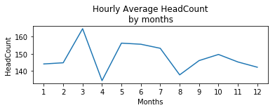

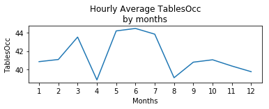

```python
# Plot monthly (1 to 12) totals for the selected attribute by using the new TimeStamp index
# What's the number of days in each month? I want to get the hourly average results for the given attribute
# So I want to divide monthly totals by the number of days in the given month times 24 hours
num_days_month = np.array([31, 29, 31, 30, 31, 30, 31, 31, 30, 31, 30, 31])

def plot_monthly(attribute, days_month):
    """Plot the hourly average for the named attribute."""
    plt.figure(figsize=(6, 1.5))
    monthly_totals_df = headcount_df.groupby([headcount_df.index.month]).sum()
    plt.plot(monthly_totals_df.loc[:, attribute].div(days_month * 24))  # divide by number of days times hours
    plt.xticks(np.arange(1,13))
    plt.title('Hourly Average {}\nby months'.format(attribute))
    plt.ylabel(attribute)
    plt.xlabel('Months')

plot_monthly('HeadCount', num_days_month)
plot_monthly('TablesOcc', num_days_month)
```

```python
# Calculate weekly (1 to 52) totals for all attributes, using the new index TimeStamp
# This line will be used to get the source of data for the function in one of the next cells
headcount_df.groupby([headcount_df.index.week]).sum()
```

| TimeStamp | Hour | TablesOcc | TablesOpen | TablesClosed | HeadCount | DayOfWeek | DayNumber |
| --- | --- | --- | --- | --- | --- | --- | --- |
| 1 | 38640 | 6704 | 8351 | 6495 | 23394 | 13440 | 530880 |
| 2 | 38600 | 6649 | 8137 | 6559 | 23493 | 13420 | 551040 |
| 3 | 38520 | 6595 | 8249 | 6447 | 22989 | 13360 | 574500 |
| 4 | 38640 | 7421 | 8962 | 5822 | 26553 | 13440 | 601440 |
| 5 | 38640 | 7242 | 8991 | 5793 | 26338 | 13440 | 624960 |
| 6 | 38640 | 7234 | 8931 | 5853 | 25975 | 13440 | 648480 |
| 7 | 38640 | 6785 | 8367 | 6417 | 23844 | 13440 | 672000 |
| 8 | 38640 | 6473 | 8199 | 6585 | 21687 | 13440 | 695520 |
| 9 | 38640 | 6580 | 8156 | 6628 | 23332 | 13440 | 719040 |
| 10 | 38600 | 6830 | 8352 | 6344 | 24763 | 13420 | 738080 |
| 11 | 38640 | 8715 | 10132 | 4652 | 35583 | 13440 | 766080 |
| 12 | 38640 | 6989 | 8512 | 6272 | 26433 | 13440 | 789600 |
| 13 | 38640 | 6785 | 8205 | 6579 | 24551 | 13440 | 813120 |
| 14 | 38640 | 6472 | 7840 | 6944 | 22632 | 13440 | 836640 |
| 15 | 38640 | 6454 | 7952 | 6832 | 22485 | 13440 | 860160 |
| 16 | 38640 | 6447 | 8137 | 6647 | 21483 | 13440 | 883680 |
| 17 | 38640 | 6651 | 8223 | 6561 | 23038 | 13440 | 907200 |
| 18 | 38633 | 7239 | 8803 | 6043 | 26361 | 13434 | 930442 |
| 19 | 38640 | 7557 | 9509 | 5443 | 26959 | 13440 | 954240 |
| 20 | 38640 | 7452 | 9501 | 5451 | 26159 | 13440 | 977760 |
| 21 | 38640 | 7647 | 9530 | 5422 | 26806 | 13440 | 1001280 |
| 22 | 38640 | 7577 | 9649 | 5303 | 25999 | 13440 | 1024800 |
| 23 | 38640 | 7353 | 9440 | 5512 | 25529 | 13440 | 1048320 |
| 24 | 38640 | 7499 | 9268 | 5684 | 26752 | 13440 | 1071840 |
| 25 | 38640 | 7338 | 9060 | 5892 | 25570 | 13440 | 1095360 |
| 26 | 38640 | 7311 | 9173 | 5779 | 25374 | 13440 | 1118880 |
| 27 | 38640 | 7754 | 9588 | 5364 | 27887 | 13440 | 1142400 |
| 28 | 38640 | 7407 | 9194 | 5758 | 25493 | 13440 | 1165920 |
| 29 | 38640 | 7239 | 9082 | 5870 | 24984 | 13440 | 1189440 |
| 30 | 38640 | 7086 | 9032 | 5920 | 24562 | 13440 | 1212960 |
| 31 | 49680 | 8570 | 10450 | 8606 | 29647 | 15840 | 364320 |
| 32 | 38640 | 6755 | 8158 | 6626 | 23968 | 13440 | 36960 |
| 33 | 38640 | 6498 | 8070 | 6714 | 22585 | 13440 | 60480 |
| 34 | 38640 | 6954 | 8330 | 6454 | 25401 | 13440 | 84000 |
| 35 | 38640 | 6601 | 8293 | 6491 | 23583 | 13440 | 107520 |
| 36 | 38640 | 7126 | 8565 | 6219 | 25261 | 13440 | 131040 |
| 37 | 39453 | 6813 | 8359 | 6293 | 24420 | 13740 | 157734 |
| 38 | 39198 | 6669 | 8107 | 6573 | 23548 | 13576 | 180712 |
| 39 | 38640 | 6738 | 8113 | 6671 | 24779 | 13440 | 201600 |
| 40 | 38640 | 6935 | 8324 | 6460 | 25297 | 13440 | 225120 |
| 41 | 38640 | 6660 | 8235 | 6549 | 24072 | 13440 | 248640 |
| 42 | 38640 | 6763 | 8244 | 6540 | 24453 | 13440 | 272160 |
| 43 | 38640 | 6920 | 8304 | 6480 | 25213 | 13440 | 295680 |
| 44 | 38640 | 6988 | 8324 | 6467 | 25755 | 13440 | 319200 |
| 45 | 38640 | 7304 | 8506 | 6278 | 27704 | 13440 | 342720 |
| 46 | 38220 | 6684 | 8296 | 6224 | 23411 | 13320 | 359880 |
| 47 | 38640 | 6805 | 8620 | 6164 | 23825 | 13440 | 389760 |
| 48 | 38640 | 6646 | 8236 | 6548 | 23382 | 13440 | 413280 |
| 49 | 38640 | 7035 | 8390 | 6394 | 25988 | 13440 | 436800 |
| 50 | 38640 | 5639 | 7136 | 7648 | 19262 | 13440 | 460320 |
| 51 | 38640 | 5595 | 7336 | 7448 | 18897 | 13440 | 483840 |
| 52 | 38640 | 8275 | 10075 | 4887 | 30834 | 13440 | 507360 |

### Busiest weeks

I divide the weekly sums by the number of hours in a week to get average figures because the only meaningful data are hourly figures. The weekly breakdowns show that the top months identified above are more or less due to individual successful weeks, like week 11. And, although week 31 has a peak, it is the first week of August and August is not among the top months because its other weeks have lower results. Go to top

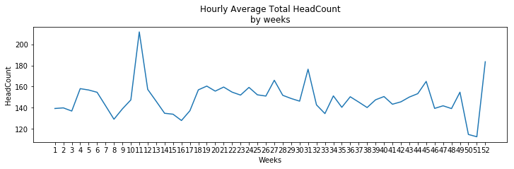

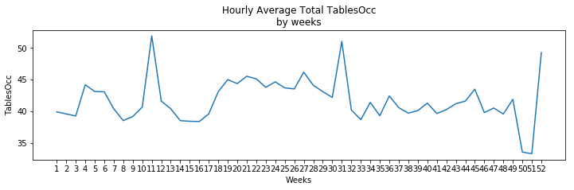

```python
# Plot weekly (1 to 52) totals for selected attributes
# See above for the source of data for this function
def plot_weekly(attribute):
    plt.figure(figsize=(12, 3))
    weekly_totals_df = headcount_df.groupby([headcount_df.index.week]).sum() / (7 * 24)  # days per week per hours
    plt.plot(weekly_totals_df.loc[:, attribute])
    plt.xticks(np.arange(1,53))
    plt.title('Hourly Average Total {}\nby weeks'.format(attribute))
    plt.ylabel(attribute)
    plt.xlabel('Weeks')

plot_weekly('HeadCount')
plot_weekly('TablesOcc')
```

### Days of week - average hourly breakdown

Each line on the following plots represent one week data for each of the 52 weeks in the year. Go to top

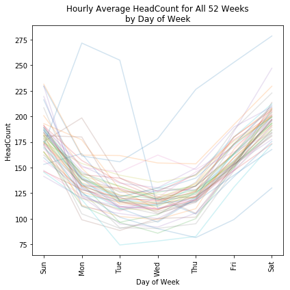

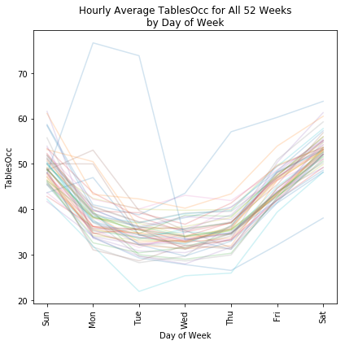

```python
# Plot within-week variability of selected attributes
# First create a new attirbute - WeekNumber
headcount_df['WeekNumber'] = headcount_df.index.week

# For each given WeekNumber, group data by DayOfWeek, sum up results, divide by 24 hour to get an average
# and plot 52 weeks with daily breakdowns
def plot_within_week(attribute):
    """Plot data grouped by weeks, summed up and divided by the number of hours."""
    plt.figure(figsize=(6, 6))
    for i in sorted(headcount_df.index.week.unique()):
        y = headcount_df[(headcount_df['WeekNumber'] == i)].groupby(['DayOfWeek'])[attribute].agg('sum') / 24
        plt.plot(y, alpha=0.2)
    plt.xticks(np.arange(1,8), ('Sun', 'Mon', 'Tue', 'Wed', 'Thu', 'Fri', 'Sat'), rotation = 90)
    plt.title('Hourly Average {} for All 52 Weeks\nby Day of Week'.format(attribute))
    plt.xlabel('Day of Week')
    plt.ylabel('{}'.format(attribute))
    plt.tight_layout()
    plt.show()

plot_within_week('HeadCount')
plot_within_week('TablesOcc')
```

The first of the above charts shows, for example, that hourly average headcount for Sundays usually ranges from 150 to 190 visitors.

### Daily averages

On the 366-day plots below, the peaks must reflect weekends and the troughs - regular days of the week. But, in general, these plots are not so convenient as the monthly and weekly plots in showing long-term trends. Go to top

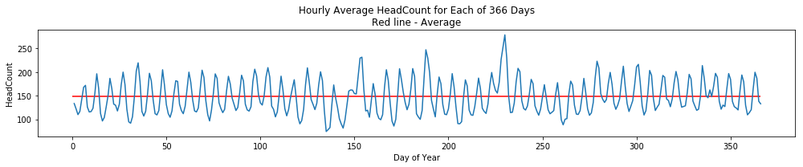

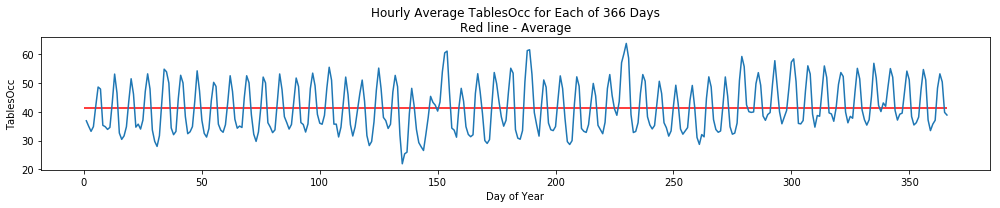

```python
# Plot daily figures for selected attributes, calculated as an average over 24 hours of the day
# For example, for Headcount, this is the number of people present on an average hour of the day in the casino
def plot_daily(attribute):
    plt.figure(figsize=(14, 3))
    y = headcount_df.groupby(['DayNumber'])[attribute].agg('sum') / 24
    plt.plot(y)
    plt.hlines(y.mean(), 0, 366, colors = 'r')
    plt.title('Hourly Average {} for Each of 366 Days\nRed line - Average'.format(attribute))
    plt.xlabel('Day of Year')
    plt.ylabel(attribute)
    plt.tight_layout()
    plt.show()

plot_daily('HeadCount')
plot_daily('TablesOcc')
```

### Hour-of-day views

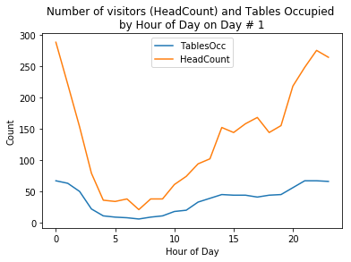

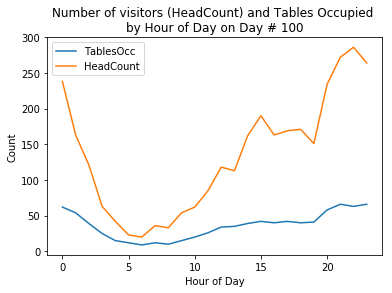

```python
# View a couple of selected days - hourly HeadCount and Occupied Tables count
def plot_day_head_occ_tables(day_num):
    """Plot by hour figures for 2 attributes for the chosen day."""
    plt.figure()
    y1 = headcount_df[(headcount_df['DayNumber'] == day_num)].groupby(['Hour'])['TablesOcc'].agg('sum')
    plt.plot(y1)
    y2 = headcount_df[(headcount_df['DayNumber'] == day_num)].groupby(['Hour'])['HeadCount'].agg('sum')
    plt.plot(y2)
    plt.legend()
    plt.title('Number of visitors (HeadCount) and Tables Occupied \nby Hour of Day on Day # {}'.format(day_num))
    plt.xlabel('Hour of Day')
    plt.ylabel('Count')
    plt.show()

plot_day_head_occ_tables(1)
plot_day_head_occ_tables(100)
```

What the above plots show is that there are peaks and troughs within the day. And in the next charts I plot all 366 days at once.

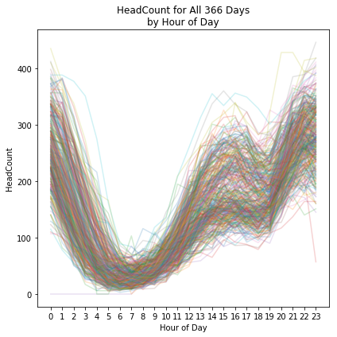

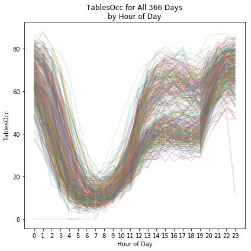

```python
# Hourly breakdown of each of 366 days at once in terms of the number of tables occupied and headcounts
def plot_hourly(attribute):
    """Plot multiple days, hour by hour figures."""
    plt.figure(figsize=(6, 6))
    for i in range(1, 367):
        y1 = headcount_df[(headcount_df['DayNumber'] == i)].groupby(['Hour'])[attribute].agg('sum')
        plt.plot(y1, alpha=0.2)
    plt.xticks(np.arange(24))
    plt.title('{} for All 366 Days\nby Hour of Day'.format(attribute))
    plt.xlabel('Hour of Day')
    plt.ylabel(attribute)
    plt.tight_layout()
    plt.show()

plot_hourly('HeadCount')
plot_hourly('TablesOcc')
```

### Most popular games

The first chart in this section is intended for exploring game-related data. It shows a snapshot for the number of people involved in each game on day 1 at hour 00 in the dataset. Go to top

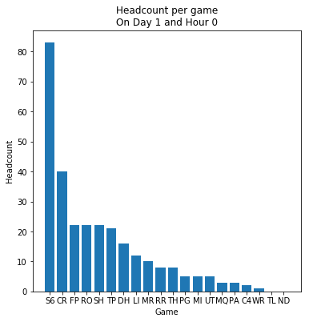

```python
# A snapshot of games - Day # 1, Hour # 0
plt.figure(figsize=(6, 6))
game_head_df = headcount_df[(headcount_df['DayNumber'] == 1) &
                            (headcount_df['Hour'] == 0)].loc[:, ['GameCode', 'HeadCount']]
x = game_head_df.sort_values('HeadCount', ascending=False)['GameCode'].values
y = game_head_df.sort_values('HeadCount', ascending=False)['HeadCount'].values
plt.bar(x, y)
plt.title('Headcount per game\nOn Day 1 and Hour 0')
plt.ylabel('Headcount')
plt.xlabel('Game')
```

The plot below extends the above snapshot by adding the other 23 hours in addition to hour 00 on the same day No. 1. In general, this plot happens to reflect that the most popular (by headcount by hour) games are S6, CR and TP, as will be shown below.

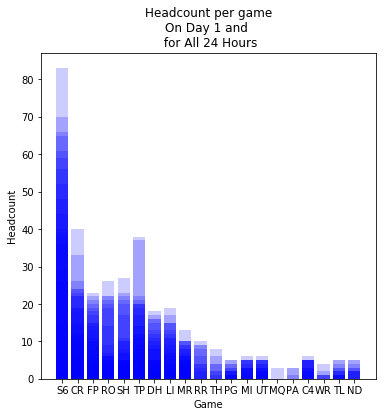

```python
# A snapshot of games - Day # 1, all 24 Hours
def plot_24_hours_games():
    plt.figure(figsize=(6, 6))
    for hour in range(24):
        game_head_df = headcount_df[(headcount_df['DayNumber'] == 1) &
                                    (headcount_df['Hour'] == hour)].loc[:, ['GameCode', 'HeadCount']]
        x = game_head_df.sort_values('HeadCount', ascending=False)['GameCode'].values
        y = game_head_df.sort_values('HeadCount', ascending=False)['HeadCount'].values
        plt.bar(x, y, alpha = 0.2, color = 'Blue')
    plt.title('Headcount per game\nOn Day 1 and \n for All 24 Hours')
    plt.ylabel('Headcount')
    plt.xlabel('Game')

plot_24_hours_games()
```

Plot the average headcount for all games for the entire year and range them by count.

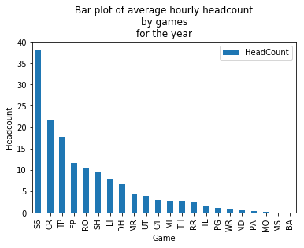

```python
res = headcount_df.loc[:, ['GameCode', 'HeadCount']].groupby(['GameCode']).agg('sum').divide(366*24)
res.sort_values('HeadCount', ascending=False).plot.bar()
plt.title('Bar plot of average hourly headcount\nby games\nfor the year')
plt.xlabel('Game')
plt.ylabel('Headcount')
```

### Create a new dataframe to focus on the games

The plots in the first part of this notebook included counts that covered all the games in aggregate. Because now I want to focus on the games, I'll re-arrange the pandas dataframe. The new dataframe will transpose GameCodes - they will become the attributes (i.e. column headings) and the headcounts will become their values, for the respective hour and date. Go to top

```python
# Create a new dataframe - headings: timestamps and games, rows: time values, dates, and headcounts values

# Create a new dataframe containing only BA game rows from the original dataframe
games_headcount_df = headcount_df[(headcount_df['GameCode'] == 'BA')]
# Rename the HeadCount to be the BA code: So now I have a column headed BA with values being headcounts by hours
new_col_names = {'HeadCount': 'BA'}
games_headcount_df = games_headcount_df.rename(columns = new_col_names)
# Remove columns I don't want to use. I will only use HeadCounts to calculate the Games popularity
games_headcount_df = games_headcount_df.drop(columns = ['GameCode','TablesOcc', 'TablesOpen', 'TablesClosed'])

# Get a list of GameCodes but exclude the 1st one because it is BA and BA was already used
game_codes_list = headcount_df['GameCode'].unique()
# Repeat the above process for each game
for game_code in game_codes_list[1:]:
    temp_df = headcount_df[(headcount_df['GameCode'] == game_code)]
    new_col_names = {'HeadCount': game_code}
    temp_df = temp_df.rename(columns = new_col_names)
    temp_df = temp_df.drop(columns = ['GameCode','TablesOcc', 'TablesOpen', 'TablesClosed'])
    # Merge each newly created dataframe with the one created at the very beginning of this cell
    games_headcount_df = pd.merge(games_headcount_df, temp_df, how = 'outer')
    # Check that I got my calculations right by comparing numbers in the new df with the old one
#     print(game_code, '=', games_headcount_df[game_code].sum())
#     print(game_code, 'must be', headcount_df[(headcount_df.loc[:, 'GameCode'] == game_code)]['HeadCount'].sum())
    res = games_headcount_df[game_code].sum()
    expect = headcount_df[(headcount_df.loc[:, 'GameCode'] == game_code)]['HeadCount'].sum()
    assert res == expect

# Re-introduce the TimeStamp index - it got lost at some stage of creating the new dataframe above
games_headcount_df['TimeStamp'] = pd.to_datetime(games_headcount_df.DateFormat) + games_headcount_df.Hour.astype('timedelta64[h]')
games_headcount_df.set_index('TimeStamp', inplace = True)
```

### Explore the new dataframe

The new dataframe transposes GameCodes - they are now the attributes (i.e. column headings) rather than values in the GameCode column and their values are now their respective headcounts for each hour and date. This way it is easier to plot Game data by using the TimeStamp index.

```python
games_headcount_df.head()
```

| TimeStamp | DateFormat | Hour | BA | DayOfWeek | DayNumber | WeekNumber | C4 | CR | DH | FP | ... | PG | RO | RR | S6 | SH | TH | TL | TP | UT | WR |
| --- | --- | --- | --- | --- | --- | --- | --- | --- | --- | --- | --- | --- | --- | --- | --- | --- | --- | --- | --- | --- | --- |
| 2011-09-16 06:00:00 | 9/16/2011 | 6 | 0.0 | 6 | 47 | 37 | 0 | 6 | 3 | 1 | ... | 0 | 0 | 0 | 0 | 4 | 0 | 0 | 4 | 5 | 0 |
| 2011-09-16 07:00:00 | 9/16/2011 | 7 | 0.0 | 6 | 47 | 37 | 0 | 7 | 5 | 0 | ... | 0 | 2 | 0 | 0 | 4 | 0 | 0 | 1 | 1 | 0 |
| 2011-09-16 08:00:00 | 9/16/2011 | 8 | 0.0 | 6 | 47 | 37 | 0 | 7 | 3 | 2 | ... | 1 | 2 | 0 | 0 | 1 | 0 | 0 | 6 | 2 | 0 |
| 2011-09-16 09:00:00 | 9/16/2011 | 9 | 0.0 | 6 | 47 | 37 | 0 | 2 | 4 | 3 | ... | 0 | 4 | 0 | 0 | 4 | 0 | 0 | 8 | 3 | 0 |
| 2011-09-16 10:00:00 | 9/16/2011 | 10 | 0.0 | 6 | 47 | 37 | 0 | 6 | 3 | 5 | ... | 0 | 12 | 0 | 0 | 4 | 0 | 0 | 9 | 3 | 0 |

5 rows × 27 columns

### Plot games by headcount by weeks

The first plot below shows the 3 top games and the second plot is just for comparision to see how far are the top three games from the rest of the group. Go to top

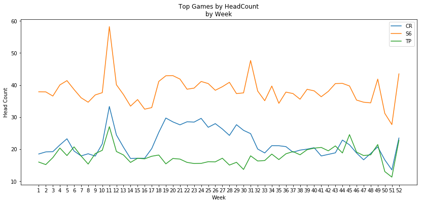

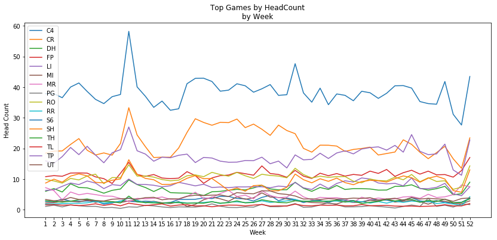

```python
# Plot Games by Head Count by week.
def plot_games_weekly(cutoff, game_codes_list):
    """Plot games by headcount with a weekly breakdown, if mean(average_headcount) is above cuttoff."""
    ax = plt.figure(figsize=(14,6)).gca()
    # Group game data by weeks. Sum up headcounts and average them by dividing by the number of hours in a week.
    totals_games_df = games_headcount_df.groupby([games_headcount_df.index.week]).sum() / (7 * 24)
    for game in game_codes_list:
        if totals_games_df[game].mean() > cutoff:
            totals_games_df.loc[:, [game]].plot(ax = ax)
    plt.legend()
    plt.xticks(np.arange(1, 53))
    plt.title('Top Games by HeadCount\nby Week')
    plt.xlabel('Week')
    plt.ylabel('Head Count')
    plt.show()

game_codes_list = headcount_df['GameCode'].unique()
plot_games_weekly(15, game_codes_list)
plot_games_weekly(1, game_codes_list)
```

Go to top